FONDECYT 1240138 · panel TSM, rondas 7–11

# Transiciones TSM v4

Qué cambia en la versión 4 del cuaderno de transiciones del Termómetro de la Salud Mental (TSM), por qué las matrices casi no se mueven, cómo queda la comparación con la EPS y qué se corrigió en el script de diseño de la ENPG, y qué dice el panel sobre la persistencia de HED. Cifras de la ejecución del 2026-10-27, que agregó esa sección sin mover ninguna tabla anterior.

Los cambios de v4 son de estructura, no de resultados. En los orígenes con datos (N0, FD y C1), ninguna celda de la matriz agregada se mueve más de 0,003 frente a v3, y el modelo elegido sigue siendo el mismo (Lognormal).

**5**estados: N0, FD, C1, C2, C3+

**±2 años**tolerancia de edad en el vínculo, elegida con datos (v3: ±1)

**4.160**pares de transición (v3: 4.121)

**≤ 0,003**cambio máximo frente a v3 en orígenes con datos

**74 / 74**tablas idénticas en dos ejecuciones; 64 controles en TRUE

1 · Qué cambió

## Cuatro cambios y por qué

C3 + C4 = C3+, dentro del modelo

C4 ya no existe como estado en TSM: no es origen, ni destino, ni aparece en el bootstrap ni en la capa anual. En v3 la fusión estaba solo en una tabla resumen. Es la misma regla de EPS v4, Puka 2022 y Kilian 2025.

Orígenes en los 4.160 pares: N0 1.613 · FD 432 · C1 2.103 · C2 6 · C3+ 6. En v3, C4 tenía 0 orígenes.

Bordes WHO y 12 g por trago

El valor exacto del borde va a la categoría inferior: C1 hasta 20 g/día en mujeres y 40 en hombres, C2 hasta 40 y 60, y C3+ por encima.

TSM no tiene ninguna observación exacta en 20, 40, 60 o 100 g/día, así que no cambia ninguna etiqueta.

Tolerancia de vínculo ±2 años

TSM toma la edad de un listado del hogar que se corrige de vez en cuando. Por eso los límites de edad de EPS se amplían hasta donde la discordancia educacional de los pares sigue en su nivel base (sección 3).

De ±1 a ±2: +39 pares (4.121 → 4.160).

Cuaderno autocontenido

Todas las funciones de datos y de modelos están escritas en el cuaderno, en 17 bloques con su explicación. Al construirlo se verifica que, juntos, coincidan byte a byte con los archivos R que usan las pruebas.

Único source() que queda: _tools/acc_data.R, la puerta obligada a los datos cifrados.

2 · Exbebedores

## ¿Cinco estados, si TSM no pregunta por exbebedores?

Sí. TSM no pregunta si alguna vez bebió, así que FD no puede salir de una respuesta, como en EPS. Sale del propio panel.

| Estado | EPS | TSM v4 |
| --- | --- | --- |
| **N0** | No bebe y no se le vio beber en ninguna entrevista anterior. EPS tampoco pregunta si alguna vez bebió; en v4, la ronda 2009 aporta historia y marca la abstinencia prolongada (Calvo 2020). | No bebe y no se le vio beber en ninguna entrevista anterior compatible. Mezcla abstemios de por vida con quienes dejaron de beber antes del panel: todo no bebedor de R7 es N0. |
| **FD** | Bebió alguna vez y ahora no bebe. | No bebe ahora y bebía en una entrevista anterior compatible, siguiendo la cadena de entrevistas. |
| **C1, C2, C3+** | Gramos por día con bordes WHO y 12 g por trago, igual en ambas fuentes. |  |

**Por qué funciona.** Los modelos predicen el destino en cuatro clases: NC, C1, C2 y C3+. Después NC se reparte según la historia: desde N0 se queda en N0 y desde cualquier otro origen pasa a FD. La división N0/FD solo entra como covariable de origen, así que no hace falta que N0 signifique «nunca bebió».

**Lo que no se puede hacer** es comparar el FD de TSM con el de EPS. En TSM, FD dejó de beber hace meses; en EPS, hace años. Por eso el cruce EPS–TSM deja fuera el origen FD (FD→FD anual: 0,28 en TSM y 0,87 en EPS).

3 · Tolerancia

## Por qué ±2 años

La educación completada no debería cambiar en pocos meses. Si un par con la edad fuera de rango fuera en realidad otra persona, la educación discreparía más que en los pares limpios. Hasta 2 años fuera de los límites estrictos, la discordancia se mantiene en el nivel de los pares estrictos; con 3 o más se duplica. En EPS, el mismo criterio llevó a ±3, porque allí las olas están separadas por años.

Pares del mismo sexo según cuántos años quedan fuera de los límites estrictos de EPS

| Años fuera | Pares | Con educación en ambas rondas | Educación distinta | Pares aceptados (acumulado) |
| --- | --- | --- | --- | --- |
| 0 (límites estrictos) | 3.888 | 3.826 | 10,5 % | 3.888 |
| 1 | 233 | 229 | 14,0 % | 4.121 v3 |
| 2 | 39 | 39 | 10,3 % | 4.160 v4 |
| 3 o más | 14 | 14 | 21,4 % | 4.174 |

El único par con distinto sexo entre rondas queda fuera. Con 3 o más años hay solo 14 pares (3 discordantes), así que la evidencia es débil, pero lo que se gana o se pierde también es poco. Tabla: `tsm_markov_outputs_v4/link_tolerance_evidence.csv`. Un control del cuaderno verifica que el acumulado en ±2 coincida con los pares del análisis principal.

4 · Resultados

## Matriz agregada: prácticamente la de v3

Transiciones por intervalo (de 4 a 8 meses), con los cuatro intervalos juntos, para el modelo Lognormal, que sigue con el mejor log loss fuera de muestra: frente a A, la diferencia es −0,021 [−0,035; −0,006] (en v3, −0,020). Los IC 95 % salen de un bootstrap de personas con B = 1000.

| Origen (pares) | N0 | FD | C1 | C2 | C3+ |
| --- | --- | --- | --- | --- | --- |
| N0 (1.613) | 0,7980,756–0,834 | 0 | 0,2020,165–0,244 | 0,000 | 0,000 |
| FD (432) | 0 | 0,4340,352–0,520 | 0,5650,479–0,647 | 0,001 | 0,000 |
| C1 (2.103) | 0 | 0,2180,188–0,252 | 0,7740,740–0,804 | 0,0050,004–0,007 | 0,0030,002–0,005 |
| C2 (6) | 0 | 0,000 | 0,759 | 0,133 | 0,108 |
| C3+ (6) | 0 | 0,087 | 0,911 | 0,001 | 0,000 |

Los ceros sin decimales son estructurales: N0 no pasa a FD y un bebedor no vuelve a N0. Las filas C2 y C3+ tienen 6 pares cada una: son extrapolación del modelo, no datos, y no tienen IC porque en algunas réplicas no aparece ningún origen.

Celdas principales, v3 → v4 (Lognormal)

| Transición | v3 (6 estados, ±1) | v4 (5 estados, ±2) |
| --- | --- | --- |
| N0 → N0 | 0,800 | 0,798 |
| N0 → C1 | 0,200 | 0,202 |
| FD → FD | 0,435 | 0,434 |
| FD → C1 | 0,564 | 0,565 |
| C1 → FD | 0,217 | 0,218 |
| C1 → C1 | 0,774 | 0,774 |

5 · Cruce con EPS

## EPS vs TSM con los estados fusionados

El cruce lee la capa anual del motor EPS v1, que sigue con seis estados. EPS v4 ya tiene cinco, pero todavía no tiene capa anual. Para comparar, la matriz EPS se lleva a cinco estados: las columnas C3 y C4 se suman, y las filas C3 y C4 se promedian ponderadas por los pares de origen EPS observados en cada una. Las celdas fusionadas quedan sin IC, porque combinarlos exige las réplicas.

Matrices anuales, modelo Lognormal (IC 95 %)

| Transición | TSM v4 | EPS | Lectura |
| --- | --- | --- | --- |
| N0 → N0 | 0,5880,514–0,659 | 0,9110,901–0,920 | TSM ve mucho más inicio de consumo |
| N0 → C1 | 0,3230,271–0,380 | 0,0760,067–0,087 |  |
| C1 → C1 | 0,7360,701–0,768 | 0,8160,786–0,843 | Más cerca |
| C1 → FD | 0,2500,219–0,285 | 0,1540,136–0,175 |  |
| C2 → C2 | 0,0116 orígenes | 0,4860,408–0,565 | TSM sin datos |
| C3+ → C3+ | 0,0076 orígenes | 0,399fusionada, sin IC | TSM sin datos |
| FD → FD | 0,2760,231–0,325 | 0,8720,828–0,906 | No comparable (ver sección 2) |

La brecha es la misma de v3: viene de una diferencia de constructo y no de calibración. TSM no fija ventana de recuerdo, sus intervalos son de 4 a 8 meses y las respuestas oscilan entre rondas.

**Por qué sube el RMSE.** El RMSE ponderado de la proyección TSM → EPS pasa de 0,198 a 0,224 en VI→VII y de 0,259 a 0,292 en VII→VIII. No es un empeoramiento. El RMSE promedia sobre las celdas de destino, y con cuatro destinos en vez de cinco los mismos errores se dividen entre menos celdas: el factor es √(5/4) = 1,118, y 0,198 × 1,118 = 0,221. Las diferencias por celda casi no cambian: N0→C1 pasa de +0,380 en v3 a +0,390 en v4.

6 · Comparación directa R7–R11

## Misma comparación a dos años, una persona más

`tsm_r7_r11_comparators.R` ahora trabaja con los estados de cada motor: seis en EPS y cinco en TSM. La condición sobre el generador compara la matriz anual de EPS después de fusionar C3 y C4 con los mismos pesos que el cruce; antes fallaba por la celda C4→C4, casi sin datos. Con las masas ponderadas, como en la publicación, pasa en los cuatro motores.

El generador reajustado debe reproducir la matriz anual publicada (diferencia < 0,02 por celda)

| Motor | Masas | Máx. dif. anual | Máx. dif. a 2 años | Condición |
| --- | --- | --- | --- | --- |
| EPS A | conteos | 0,083 | 0,0133 | no pasa |
| EPS A | ponderadas | 0,006 | 0,0013 | pasa |
| EPS Lognormal | conteos | 0,027 | 0,0214 | no pasa |
| EPS Lognormal | ponderadas | 0,006 | 0,0008 | pasa |
| TSM A | conteos | 0,009 | 0,0063 | pasa |
| TSM A | ponderadas | 0,002 | 0,0004 | pasa |
| TSM Lognormal | conteos | 0,041 | 0,0558 | no pasa |
| TSM Lognormal | ponderadas | 0,006 | 0,0009 | pasa |

A dos años, 903 personas: observado (IC 95 %) y predicción puntual de cada motor

| Transición | Observado | EPS A | TSM A | TSM Lognormal | JRT original | Rangos |
| --- | --- | --- | --- | --- | --- | --- |
| NC → sigue NC (410) | 71 %61–80 % | 85 % | 50 % | 51 % | 97 % | 94 % |
| C1 → sigue C1 (489) | 77 %70–83 % | 68 % | 73 % | 73 % | 90 % | 93 % |
| C1 → deja de beber (489) | 21 %15–28 % | 28 % | 25 % | 25 % | 9 % | 6 % |

Frente a la corrida del 20 de octubre, los analizables pasan de 902 a 903: la tolerancia ±2 recupera a una mujer de 30–44 años con origen C1. Las cifras globales se mueven a lo más 1 punto y las conclusiones no cambian. TSM reproduce C1 pero no la permanencia sin consumo; JRT original y el rank matching sobrestiman la estabilidad. Las tablas completas, por sexo × edad y por educación, están en `tsm_r7_r11_directo.md`. La página anterior, con seis estados y ±1, quedó con un aviso.

7 · Diseño ENPG

## `revision_diseno_enpg_extension.R`: misma población que `expand_pif`

El script calcula, por año × tramo de edad × sexo, el tamaño efectivo de Kish y un factor de conglomerado (PSU + región). Solo lo usa `expand_pif.ipynb`, en la celda `enpg-kish-PSU-corr`, y de ahí pasa a `aaf_unified.R`. Define el ancho de los IC Monte Carlo de AAF, PIF y AVPP, nunca la estimación puntual. Antes derivaba las variables a su manera, así que medía la precisión de otra población; ahora replica fila por fila la celda `enpg-consolidate`.

| Qué se corrigió | Antes | Ahora (= expand_pif) |
| --- | --- | --- |
| Bebedor actual sin volumen o con volumen 0 | quedaba fuera de abs/form | `cur_na`: dentro del denominador |
| «Sí ha bebido» sin fecha del último consumo | contado como exbebedor | estado desconocido: fuera |
| Más de 30 días de consumo, o abstemio con fecha | se mantenían | se excluyen |
| Población de HED y consumo | todo bebedor actual con datos | bebedores con volumen positivo |
| Volumen | 15,7 g, anclaje fijo de 7,9 L | 12 g, factor WHO por año |
| Categorías | cortes JRT con huecos | bordes WHO sin huecos |

Efecto en las 56 celdas de cada variable

| Variable | n total antes → ahora | n efectivo corregido, ahora / antes |
| --- | --- | --- |
| Abstemio de por vida | 120.015 → 122.968 | 0,90 a 1,12 |
| Exbebedor | 120.015 → 122.968 | 0,92 a 1,24 |
| HED | 45.361 → 44.868 | 0,95 a 1,01 |
| Consumo (g/día) | 44.880 → 44.868 | 1,00 a 1,00 |

Verificado contra los datos que guarda `expand_pif`: la tabla año × estado y los bebedores con volumen positivo son idénticos, y el volumen medio por año coincide. El script se detiene si las cuatro poblaciones no son las esperadas. **Pendiente:** reejecutar `expand_pif` para que sus IC usen los nuevos factores. Detalle: `revision_diseno_enpg_extension.md`.

8 · Persistencia de HED · exploratorio

## ¿Cuánto aporta saber que hubo HED antes, además del volumen?

El motor de microsimulación asigna el HED cada año con una logística sobre el volumen (una celda por sexo × edad más log(1+g)) y una tendencia propia, `z_hed`, que se arrastra de un año al siguiente con ρ = 0,8. Ese 0,8 es un supuesto. Esta sección resume lo que dice el panel TSM. El análisis vive ahora en el propio cuaderno TSM v4 (sección *HED persistence beyond volume*), que corrió dos veces con tablas idénticas.

TSM aporta evidencia de dependencia del HED más allá del volumen medido, cuya magnitud cambia según la definición de HED. Para el HED que mide TSM, la evaluación conjunta de los cinco plazos (4 a 24 meses) es incompatible con el supuesto actual del motor, una correlación anual efectiva de 0,8, y también con cualquier AR(1) sin componente de ocasión, si la caída dentro del año es exponencial. Respalda una correlación anual efectiva r(1) entre 0,24 y 0,36. No es un rechazo formal del parámetro trasladado a ENPG, y no establece el mecanismo ni su duración: φ queda poco identificado (0,67 a 1,00), y la correlación a 10 años compatible con los datos va de 0,00 a 0,38. Para proyectar, conviene variar por separado r(1) y φ, como escenarios y no como un intervalo validado, y evaluar cuánto cambian los resultados de DIR.

**Definiciones.** HED en TSM = al menos una ocasión con 6 o más tragos (`e3a3` distinto de «Nunca»), la variable `hed6` de v4, solo entre quienes beben. Volumen = g/día de v4, con 12 g por trago. Pares de rondas consecutivas con vínculo compatible; el análisis principal usa quienes beben en ambas rondas y los pesos IPW de v4.

### Tres cantidades que no hay que confundir

| Término | Qué es | Motor actual |
| --- | --- | --- |
| **r(1)** | Correlación efectiva de la tendencia al HED entre dos años seguidos | 0,8 |
| **φ** | Cuánto conserva cada año la parte persistente: qué tan rápido decae | 0,8 |
| **R = r(1)/φ** | Fracción de la varianza que es persistente; el resto es un componente de cada ocasión que no se arrastra | 1 |

La correlación a d años es R × φ<sup>d</sup>. El motor tiene una innovación aleatoria cada año, pero toda pasa a la parte persistente: no tiene un componente de ocasión, por eso R = 1 y r(1) = φ. Con un componente de ocasión, r(1) puede ser bajo aunque φ sea alto. Los plazos menores de un año entran como meses/12, lo que supone una caída exponencial dentro del año: el motor solo tiene pasos anuales.

### Tablas

Transiciones entre rondas consecutivas, % por fila (IPW)

| Ronda t | Pares | No bebe | Bebe, sin HED | Bebe, con HED |
| --- | --- | --- | --- | --- |
| No bebe | 2.045 | 72,9 | 20,4 | 6,7 |
| Bebe, sin HED | 1.496 | 24,4 | 59,2 | 16,4 |
| Bebe, con HED | 619 | 15,8 | 39,9 | 44,3 |

HED en t+1 según HED en t, entre quienes beben en ambas rondas (IPW)

| Grupo | Pares | Con HED en t | Si tuvo HED en t | Si no tuvo |
| --- | --- | --- | --- | --- |
| Volumen en t+1 hasta 2 g/día | 1.113 | 278 | 41,1 % | 14,7 % |
| Volumen en t+1 de 2 a 10 g/día | 401 | 181 | 65,3 % | 40,2 % |
| Volumen en t+1 sobre 10 g/día | 85 | 53 | 61,0 % | 45,4 % |
| Hombres | 777 | 303 | 56,8 % | 26,8 % |
| Mujeres | 822 | 209 | 43,8 % | 16,0 % |
| Todos | 1.599 | 512 | 52,6 % | 21,7 % |

Dentro de cada tramo de volumen, quien tuvo HED vuelve a tenerlo bastante más que quien no lo tuvo: el volumen no explica toda la diferencia.

### Transición logística

HED en t+1: OR del HED previo (errores agrupados por persona, IPW) y validación cruzada por persona

| Volumen en el modelo | OR del HED en t | AUC sin → con | Log loss sin → con |
| --- | --- | --- | --- |
| Volumen en t (predicción pura) | 3,001,92 a 4,70 | 0,649 → 0,682 | 0,589 → 0,571 |
| Volumen en t+1 (como el motor) | 2,961,91 a 4,59 | 0,705 → 0,732 | 0,558 → 0,540 |
| Volumen en t y en t+1 | 2,841,78 a 4,53 | → 0,733 | → 0,540 |

Todos los modelos incluyen sexo × edad. Agregar el HED previo al modelo con volumen en t+1 mejora el log loss en 13 de 15 particiones; son repeticiones de 5 particiones, no pruebas independientes.

### La misma estructura del motor: una cópula gaussiana

En el motor, HED = 1 cuando Φ(Z) < p. Entonces la probabilidad de HED en dos entrevistas es la normal bivariada en (Φ⁻¹(p<sub>t</sub>), Φ⁻¹(p<sub>t'</sub>)) con correlación ρ. Estimar ese ρ con el margen del motor da su mismo parámetro, después de descontar el volumen.

ρ entre rondas consecutivas (4 a 8 meses), quienes beben en ambas; IC 95 % por bootstrap de personas (1.000 réplicas, IPW reestimado)

| Especificación | Pares | ρ |
| --- | --- | --- |
| Margen del motor, con IPW (principal) | 1.599 | 0,330,14 a 0,46 |
| Margen del motor, sin IPW | 1.599 | 0,270,16 a 0,35 |
| Margen saturado: una categoría por banda de frecuencia × tragos, con IPW | 1.599 | 0,280,09 a 0,41 |
| Solo quienes beben 2 o más veces al mes en ambas rondas, con IPW | 599 | 0,370,14 a 0,52 |
| HED mensual o más frecuente (prevalencia cercana a 9 %), con IPW | 1.599 | 0,00−0,25 a 0,20 |
| Efecto del IPW (con menos sin) | 1.599 | 0,06−0,08 a 0,17 |
| Margen y ρ en una sola verosimilitud (núcleo de GJRM), solo punto | 1.599 | 0,34 |

- **La forma del margen pesa poco:** con un margen saturado, ρ cambia poco. Eso muestra robustez a cómo se modela el volumen medido, no que el volumen esté bien medido.
- **Con HED mensual, la dependencia es menor:** el intervalo excluye 0,3. No significa independencia: un umbral raro también amplifica el ruido de respuesta.
- **GJRM:** la estimación conjunta del margen y ρ, el núcleo de GJRM, da casi lo mismo que la de dos pasos. Por ahora no aporta; serviría para ρ por sexo o edad, cópulas asimétricas o un modelo conjunto de seguir bebiendo y tener HED. No está en `renv`.

### Cinco distancias y qué combinaciones de r(1) y φ respalda TSM

ρ según la distancia entre rondas: todos los pares compatibles de quienes beben en ambas (sin IPW)

| Distancia | Pares de rondas | Pares | Personas | ρ |
| --- | --- | --- | --- | --- |
| 4 a 5 meses | R8-R9, R10-R11 | 717 | 588 | 0,240,09 a 0,37 |
| 7 a 8 meses | R7-R8, R9-R10 | 882 | 723 | 0,280,15 a 0,38 |
| 11 a 12 meses | R7-R9, R8-R10, R9-R11 | 1.197 | 787 | 0,340,23 a 0,42 |
| 16 a 19 meses | R7-R10, R8-R11 | 734 | 589 | 0,350,22 a 0,44 |
| 24 meses | R7-R11 | 369 | 369 | 0,08−0,15 a 0,24 |

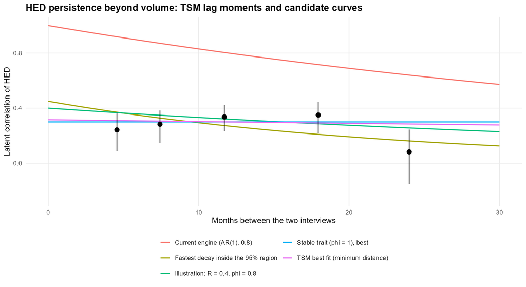

Se ajusta la curva R·φ<sup>meses/12</sup> a las cinco distancias por mínima distancia. La covarianza de las cinco estimaciones sale del bootstrap por persona, porque las mismas personas aparecen en varias distancias. Con las cinco distancias, una sola curva no se rechaza al 5 % (p = 0,06), aunque el par de 24 meses queda por debajo de ella; sin ese par, p = 0,34.

Ajuste por mínima distancia de R·φ^(meses/12)

| Momentos | Distancia mínima | Valor p | Mejor r(1) | Mejor φ |
| --- | --- | --- | --- | --- |
| Cinco distancias | 7,25 | 0,064 | 0,30 | 0,95 |
| Sin el par de 24 meses | 2,16 | 0,340 | 0,31 | 1,00 |

Qué respalda TSM y qué queda como supuesto

| Cantidad | Cinco distancias | Sin 24 meses | Lectura |
| --- | --- | --- | --- |
| r(1), perfil al 95 % | 0,24 a 0,36 | 0,25 a 0,38 | lo respaldan los datos |
| φ, perfil al 95 % | 0,67 a 1,00 | 0,79 a 1,00 | poco identificado |
| R dentro de la región | 0,22 a 0,49 | 0,23 a 0,44 | lo respaldan los datos |
| Correlación a 5 años dentro de la región | 0,03 a 0,38 | 0,08 a 0,40 | supuesto (extrapolación) |
| Correlación a 10 años dentro de la región | 0,00 a 0,38 | 0,01 a 0,40 | supuesto (extrapolación) |

Los rangos de r(1) y φ son perfiles al 95 %: un parámetro a la vez, con el otro en su mejor valor (chi-cuadrado con 1 grado de libertad). R y las correlaciones a 5 y 10 años recorren la región conjunta al 95 % (2 grados de libertad), que es más amplia. Por eso hay escenarios dentro de la región con φ o r(1) fuera de los perfiles, como la caída más rápida (φ = 0,60).

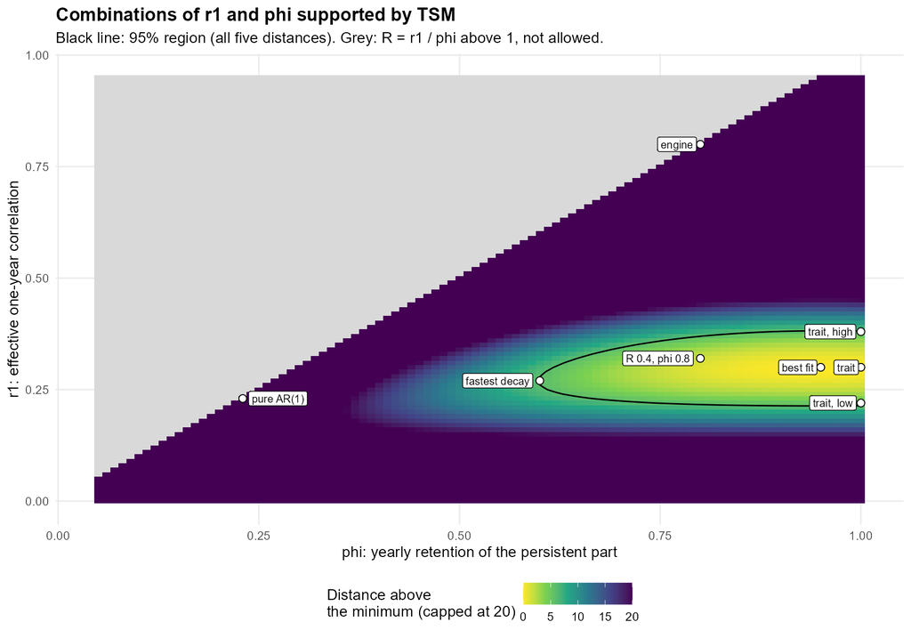

Escenarios con nombre: respaldo de TSM y correlaciones implícitas (insumo para el motor y DIR)

| Escenario | r(1) | φ | R | En la región (5 distancias) | Sin 24 meses | A 2 años | A 10 años |
| --- | --- | --- | --- | --- | --- | --- | --- |
| Mejor ajuste de TSM (mínima distancia) | 0,30 | 0,95 | 0,32 | dentro | dentro | 0,28 | 0,189 |
| Rasgo estable (φ = 1), mejor | 0,30 | 1,00 | 0,30 | dentro | dentro | 0,30 | 0,300 |
| Rasgo estable, r(1) más bajo respaldado | 0,22 | 1,00 | 0,22 | dentro | fuera | 0,22 | 0,220 |
| Rasgo estable, r(1) más alto respaldado | 0,38 | 1,00 | 0,38 | dentro | dentro | 0,38 | 0,380 |
| Caída más rápida dentro de la región | 0,27 | 0,60 | 0,45 | dentro | fuera | 0,16 | 0,003 |
| AR(1) puro, sin componente de ocasión (R = 1), mejor | 0,23 | 0,23 | 1,00 | fuera | fuera | 0,05 | 0,000 |
| Ilustración de Codex: R = 0,4 y φ = 0,8 | 0,32 | 0,80 | 0,40 | dentro | dentro | 0,26 | 0,043 |
| Motor actual: AR(1), 0,8 | 0,80 | 0,80 | 1,00 | fuera | fuera | 0,64 | 0,107 |

Lo que TSM sostiene

- El HED previo aporta información más allá del volumen, el sexo y la edad (OR entre 2,84 y 3,00). No muestra causalidad ni un rasgo biológico.
- r(1) entre 0,24 y 0,36; a 12 meses directos y sin IPW, ρ = 0,34 (0,23 a 0,42).
- Para el HED de TSM, el motor actual (0,8) queda fuera y también cualquier AR(1) sin componente de ocasión, si la caída dentro del año es exponencial.

Lo que queda como supuesto o escenario

- φ: qué tan rápido decae la parte persistente (0,67 a 1,00).
- Toda correlación más allá de 24 meses (a 5 o 10 años).
- El traslado a la pregunta de ENPG (30 días, 5+/4+): su dirección es una hipótesis.
- La caída exponencial dentro del año.

El único par a 24 meses (R7–R11) da ρ = 0,08 (−0,15 a 0,24), por debajo de las otras distancias. Es el par más afectado por las pérdidas y la fecha de R11 no está verificada; por eso el ajuste se repite sin él (r(1) 0,25 a 0,38; φ 0,79 a 1,00).

### Límites de transporte

- **Otra pregunta de HED:** TSM pregunta con qué frecuencia toma 6 o más tragos (72 g), sin ventana de tiempo, con el mismo umbral para ambos sexos; el margen del motor viene de ENPG, con 5+ tragos en hombres y 4+ en mujeres en los últimos 30 días.
- **Otra medida de volumen:** en TSM los gramos salen de bandas de frecuencia y tragos típicos, con otra pendiente que en el motor. ρ se define respecto de su margen, así que no se copia tal cual: se calibra por simulación.
- **Población y pesos:** panel telefónico urbano de 18–65 años, solo quienes beben en ambas rondas; los pares de varias distancias no tienen IPW y comparten personas.
- **Medición:** una sola pregunta telefónica clasifica con ruido; reproducir una prevalencia no garantiza reproducir las trayectorias.

### La discusión, en corto

Este resultado salió de una revisión cruzada entre Claude, tres revisores automáticos y Codex. Son controles internos sobre el mismo código y los mismos datos, no una replicación independiente. Lo que se corrigió:

| Tema | Primera versión | Corrección | Cómo quedó |
| --- | --- | --- | --- |
| «ρ anual = 0,10» | Convertido desde los pares de 4–8 meses | Revisores: era una extrapolación AR(1), no una estimación | Eliminado; se mide directo a 12 meses |
| «No es un AR(1)» | Por el orden: ρ menor a 4–8 meses que a 12 | Codex: el orden no descarta nada; el argumento es el nivel y supone caída exponencial dentro del año | Evaluado en conjunto (mínima distancia con covarianza por persona) |
| HED mensual | «No distingue 0 de 0,3» | Codex: el intervalo sí excluye 0,3 | Menor dependencia con esa definición, sin afirmar independencia |
| Margen saturado | «La persistencia no es volumen mal medido» | Codex: solo muestra robustez a la forma del margen | Reformulado |
| Ruido de medición | «TSM y ENPG tienen el mismo ruido» | Codex: no está demostrado | Quitado |
| Parámetros | Un solo ρ | Codex: distinguir r(1) de φ | r(1), φ y R = r(1)/φ |
| El motor | «No tiene ruido» | Codex: tiene innovación anual; le falta un componente de ocasión que no se arrastre | Reformulado |
| ρ compartido | — | Codex: el mismo ρ mueve consumo, volumen y HED | El cambio iría solo en `z_hed` |
| Traslado a ENPG | «Probablemente menos dependencia» | Codex: cambian ventana, umbral, población y pregunta | Hipótesis |
| Par a 24 meses | Agregado con 16–19 meses | Codex: R7–R11 sola da un ρ mucho menor; conservar esa heterogeneidad | Distancia propia en el ajuste principal; sensibilidad sin R7–R11 |
| «φ entre 0,6 y 1» | Presentado como rango | Codex: era una grilla, no un resultado | Perfil y región al 95 % estimados |
| Bootstrap | 150–200 réplicas | Codex: límites inestables | 1.000 réplicas con IPW reestimado |
| Reproducibilidad | Scripts temporales | Codex y el usuario: el análisis debe estar en el cuaderno | Sección del cuaderno, que es la fuente única desde el 2026-10-27 |

### Implicancias para el motor y para DIR

- **Separar los ρ:** el motor usa un solo ρ para consumo, volumen y HED. Una revisión de HED necesita un parámetro propio para `z_hed`.
- **Dos componentes:** una parte persistente con retención φ (φ = 1 es un rasgo estable) más un componente de ocasión, parametrizados con r(1) y φ: R = r(1)/φ, comprobando que no pase de 1.
- **Escenarios:** los de la tabla que quedan dentro de la región, más el motor actual como referencia. No son un intervalo validado: falta el traslado a ENPG.
- **DIR:** correr la evaluación con cada escenario. Si los resultados agregados apenas cambian, se mantiene una especificación simple y se documenta la sensibilidad. Eso no valida las trayectorias individuales ni asegura lo mismo para la exposición repetida o para resultados por grupo.
- **Otra fuente, otra escala:** la auditoría de persistencia del 2026-10-09 (`auditoria_microsim_2026-10-09/persistence.md`) encontró en EPS (50 años o más, de 3,7 a 7,7 años entre entrevistas) correlaciones de los g/día casi planas, de 0,33 a 0,39, y un HED aproximado también dominado por un rasgo. Es otra encuesta, otra pregunta y otros plazos, así que no se suma como evidencia del mismo parámetro. Sí es compatible con φ cercano a 1 a varios años, justo lo que TSM no puede resolver, y sirve para elegir qué escenarios comparar en DIR.
- **Qué no cambia, en principio:** la prevalencia de HED, porque `z_hed` sigue siendo N(0,1). Cambia quién tiene HED año tras año, y con eso la concentración de la exposición. Con políticas dirigidas, selección o supervivencia que dependa de la exposición, la prevalencia tampoco queda garantizada.

Cuaderno `TSM_ENPG_v4_EN.ipynb`, sección *HED persistence beyond volume*; tablas `hed_persistence_*.csv` en `tsm_markov_outputs_v4/`. Ejecutado dos veces en núcleos E con tablas idénticas. Las cifras de resultados de esta sección salen de esas tablas, no se escribieron a mano; la columna «Primera versión» resume la exploración previa.

9 · Archivos y pendientes

## Dónde está cada cosa

- Cuaderno: `__andres_control/TSM_ENPG_v4_EN.ipynb`, ejecutado dos veces a la vez en núcleos E (59 min cada una) con 74 tablas idénticas. Las 61 tablas anteriores a la sección de HED son idénticas byte a byte a las del 2026-10-26. HTML: `TSM_ENPG_v4_EN.html` en la raíz, con todas las imágenes incrustadas.
- Desde el 2026-10-27 el cuaderno es la fuente única y se edita directamente. El constructor, `tsm_markov_sections.R` y `TSM_ENPG_v4_EN.md` se borraron (quedan en el historial de git). `tsm_markov_data.R` y `tsm_markov_models.R` siguen en uso por los scripts de R7–R11, `encavi_tsm_explicado.R` y las pruebas; un cambio en ellos debe replicarse en el cuaderno.
- Salidas agregadas: `tsm_markov_outputs_v4/`, con las tablas `hed_persistence_*.csv` de la sección 8. El cuaderno v3 y sus salidas (`tsm_markov_outputs/`) quedan como historia. Verificación: `_tools/verify_tsm_reproduction.py`, que también registra un hash del código del cuaderno.
- R7–R11: `tsm_r7_r11_directo.md` y `tsm_r7_r11_direct_outputs/`. Diseño ENPG: `revision_diseno_enpg_extension.md`.

### Pendientes

- Reejecutar `expand_pif` para que sus IC de AAF, PIF y AVPP usen los nuevos factores de diseño.
- Capa anual de cinco estados en EPS v4; mientras no exista, el cruce usa EPS v1 fusionado.
- En `v2_regression_check.csv`, la columna de la versión actual todavía se llama «v3». Es solo la etiqueta; las cifras son de v4.
- La página publicada de R7–R11 no se reconstruyó; las cifras vigentes están en el md.
- Persistencia de HED (sección 8), pasos siguientes fuera del alcance de v4: darle a `z_hed` un ρ propio en el motor; parametrizarlo con dos componentes, r(1) y φ (R = r(1)/φ ≤ 1); correr DIR con los escenarios de `hed_persistence_scenarios.csv` que quedan dentro de la región, más el motor actual como referencia; y revisar el traslado a la pregunta de ENPG antes de tratar cualquier escenario como calibrado. Tocar los cuadernos del motor requiere un permiso aparte.